# Module 5: Nonparametric Statistical Methods / Sampling and Simulation

Rhea Thoppil, ALY6015 Intermediate Analytics

2024-02-10

# Introduction:

In this assignment, we have explored a variety of nonparametric statistical methods to test hypotheses and examine relationships within different sets of data. Nonparametric methods are particularly useful when the assumptions necessary for parametric tests are not met, such as when data does not follow a normal distribution or when dealing with ordinal data. We have utilized tests including the Sign Test, Wilcoxon Rank Sum Test, Spearman Rank Correlation Coefficient, and the Kruskal-Wallis Test to conduct our analyses. Through these methods, we have sought to understand underlying distributions, measure correlations, and compare medians across groups.

# *Section 13-2*

## Task 1 (13-2.6) Game Attendance

An athletic director suggests the median number for the paid attendance at 20 local football games is 3000. The data for a random sample are shown. At α = 0.05, is there enough evidence to reject the claim? If you were printing the programs for the games, would you use this figure as a guide?

| Col1 | Col2 | Col3 | Col4 | Col5 |
| --- | --- | --- | --- | --- |
| 6210 | 3150 | 2700 | 3012 | 4875 |
| 3540 | 6127 | 2581 | 2642 | 2573 |
| 2792 | 2800 | 2500 | 3700 | 6030 |
| 5437 | 2758 | 3490 | 2851 | 2720 |

## Task 1 Solution:

## **Step 1. State the hypotheses and identify the claim :**

- Null Hypothesis: The median attendance at local football games is 3000.
- Alternative Hypothesis: The median attendance at local football games is not 3000.
- The claim is that the median attendance is 3000.

## Step 2. **Critical Value:**

```r
alpha <- 0.05
```

## **Step 3. Compute the Test Value:**

```r
#Creating a vector
game_attendance <- c(6210, 3150, 2700, 3012, 4875, 3540, 6127, 2581, 2642, 2573,
                2792, 2800, 2500, 3700, 6030, 5437, 2758, 3490, 2851, 2720)

# Hypothesized median
median_task1 <- 3000

# Calculating differences from the hypothesized median
differences_task1 <- game_attendance - median_task1

#Determining the median attendance above 3000

postive_task1 <- length(differences_task1[differences_task1>0])

#Determining the median attendance below 3000
negative_task1 <- length(differences_task1[differences_task1<0])

# Perform the binomial test
binom_test_result_task1 <- binom.test(x = c(postive_task1, negative_task1), alternative = "two.sided")

# Print the test result
print(binom_test_result_task1)
```

```
##
##  Exact binomial test
##
## data:  c(postive_task1, negative_task1)
## number of successes = 10, number of trials = 20, p-value = 1
## alternative hypothesis: true probability of success is not equal to 0.5
## 95 percent confidence interval:
##  0.2719578 0.7280422
## sample estimates:
## probability of success
##                    0.5
```

## Step 4. Make the decision

```r
#Printing the p-value

binom_test_result_task1$p.value
```

```
## [1] 1
```

```r
#Determine if we should reject/accept the null hypothesis

ifelse(binom_test_result_task1$p.value>alpha, "fail to reject the null hypothesis","reject the null hypothesis")
```

```
## [1] "fail to reject the null hypothesis"
```

## Step 5. Summary

As the `p-value` turns out to be 1, and is greater than the .05 significance level, **we do not reject the null hypothesis**. At .05 significance level, we do not reject the notion that the median attendance at local football game is 3000.

**Q. If you were printing the programs for the games, would you use this figure as a guide?**

A> If we are responsible for printing the programs for the games and need to decide on the number of programs to print based on expected attendance, it would be reasonable to use the figure of 3000 as a guide.

## Task 2. (13-2.10) Lottery Ticket Sales

A lottery outlet owner hypothesizes that she sells 200 lottery tickets a day. She randomly sampled 40 days and found that on 15 days she sold fewer than 200 tickets.  
At α = 0.05, is there sufficient evidence to conclude that the median is below 200 tickets?

## Task 2 Solution:

## **Step 1. State the hypotheses and identify the claim :**

- Null Hypothesis: The median number of lottery tickets sold per day is 200.
- Alternative Hypothesis: The median number of lottery tickets sold per day is less than 200.
- The claim is that the median number of tickets sold is 200.

## Step 2. **Critical Value:**

alpha = 0.05

## **Step 3. Compute the Test Value:**

```r
#Number of days sampled
n_days <- 40

#Number of days with fewer than 200 tickets sold
n_fewer_200 <- 15

# Perform the binomial test
binom_test_result_task2 <- binom.test(x = n_fewer_200, n = n_days, p = 0.5, alternative = "less")

# Print the test result
print(binom_test_result_task2)
```

```
##
##  Exact binomial test
##
## data:  n_fewer_200 and n_days
## number of successes = 15, number of trials = 40, p-value = 0.07693
## alternative hypothesis: true probability of success is less than 0.5
## 95 percent confidence interval:
##  0.0000000 0.5172483
## sample estimates:
## probability of success
##                  0.375
```

## Step 4. Make the decision

```r
#Printing the p-value

binom_test_result_task2$p.value
```

```
## [1] 0.07692997
```

```r
#Determine if we should reject/accept the null hypothesis

ifelse(binom_test_result_task2$p.value>alpha, "fail to reject the null hypothesis","reject the null hypothesis")
```

```
## [1] "fail to reject the null hypothesis"
```

## Step 5. Summary

As the `p-value` turns out to be 0.076, and is greater than the .05 significance level, **we do not reject the null hypothesis**. At .05 significance level, we do not reject the notion that the median number of lottery tickets sold per day is 200.

# *Section 13-3*

## Task 3. (13-3.4) Lengths of Prison Sentences

A random sample of men and women in prison was asked to give the length of sentence each received  
for a certain type of crime. At α = 0.05, test the claim that there is no difference in the sentence received by each gender. The data (in months) are shown here.

## Task 3 Solution:

## **Step 1. State the hypothesis and identify the claim :**

- Null Hypothesis: The median sentence length for males is equal to the median sentence length for females.
- Alternative Hypothesis: The median sentence length for males is not equal to the median sentence length for females.
- The claim is that there is no difference in sentence lengths between genders.

## Step 2. **Critical Value:**

alpha = 0.05

## **Step 3. Compute the Test Value:**

```r
# Data for males and females
males_sentence_lengths <- c(8, 12, 6, 14, 22, 27, 32, 24, 26, 19, 15, 13)
females_sentence_lengths <- c(7, 5, 2, 3, 21, 26, 30, 9, 4, 17, 23, 12, 11, 16)

#Performing the Wilcoxon rank sum test (Mann-Whitney U test)
wilcox_test_result_task3 <- wilcox.test(x=males_sentence_lengths,y=females_sentence_lengths, alternative = "two.sided", correct = FALSE)
# Print the test result
print(wilcox_test_result_task3)
```

```
##
##  Wilcoxon rank sum test
##
## data:  males_sentence_lengths and females_sentence_lengths
## W = 113, p-value = 0.1357
## alternative hypothesis: true location shift is not equal to 0
```

## Step 4. Make the decision:

```r
#Printing the p-value

wilcox_test_result_task3$p.value
```

```
## [1] 0.1356705
```

```r
#Determine if we should reject/accept the null hypothesis

ifelse(wilcox_test_result_task3$p.value>alpha, "fail to reject the null hypothesis","reject the null hypothesis")
```

```
## [1] "fail to reject the null hypothesis"
```

## Step 5. Summary:

As the `p-value` turns out to be 0.135, and is greater than the .05 significance level, **we do not reject the null hypothesis**. At .05 significance level, we do not reject the notion that the median sentence length for males is equal to the median sentence length for females.

## Task 4. (13-3.8) Winning Baseball Games

For the years 1970–1993 the National League (NL) and the American League (AL) (major league baseball) were each divided into two divisions: East and West. Below are random samples of the number of games won by each league’s Eastern Division. At α = 0.05, is there sufficient evidence to conclude a difference in the number of wins?

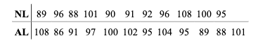

## **Task 4 Solution:**

## **Step 1. State the hypotheses and identify the claim:**

- Null Hypothesis : The median number of wins for the NL and AL Eastern Division teams are equal.
- Alternative Hypothesis: The median number of wins for the NL and AL Eastern Division teams are not equal.
- The claim is that there is no difference in the number of wins between the two divisions.

## **Step 2. Critical Value:**

alpha = 0.05

## **Step 3. Compute the Test Value:**

```r
# Data for NL and AL teams
nl_wins <- c(89, 96, 88, 101, 90, 91, 92, 96, 108, 100, 95)
al_wins <- c(108, 86, 91, 97, 100, 102, 95, 104, 95, 89, 88, 101)

# Perform the Wilcoxon rank sum test (Mann-Whitney U test)
wilcox_test_result_task4 <- wilcox.test(x = nl_wins, y = al_wins, alternative = "two.sided", correct = FALSE)
# Print the test result
print(wilcox_test_result_task4)
```

```
##
##  Wilcoxon rank sum test
##
## data:  nl_wins and al_wins
## W = 59, p-value = 0.6657
## alternative hypothesis: true location shift is not equal to 0
```

## **Step 4. Make the decision:**

```r
#Printing the p-value

wilcox_test_result_task4$p.value
```

```
## [1] 0.6657445
```

```r
#Determine if we should reject/accept the null hypothesis

ifelse(wilcox_test_result_task4$p.value>alpha, "fail to reject the null hypothesis","reject the null hypothesis")
```

```
## [1] "fail to reject the null hypothesis"
```

## Step 5. Summary:

As the `p-value` turns out to be 0.665, and is greater than the .05 significance level, **we do not reject the null hypothesis**. At .05 significance level, we do not reject the notion that the median number of wins for the NL and AL Eastern Division teams are equal.

# *Section 13-4*

## Task 5. (13-4.A)

Use Table K (or relevant software) to determine whether the null hypothesis should be rejected.  
• ws = 13, n = 15, α = 0.01, two-tailed  
• ws = 32, n = 28, α = 0.025, one-tailed  
• ws = 65, n = 20, α = 0.05, one-tailed  
• ws = 22, n = 14, α = 0.10, two-tailed

## Task 5 Solution:

## **Step 1. State the hypothesis and identify the claim:**

- Null Hypothesis: The population median difference is zero.
- Alternative Hypothesis: The population median difference is greater than (or less than) zero.

## Step 2. **Critical Value:**

## α = 0.01, two-tailed α = 0.025, one-tailed α = 0.05, one-tailed α = 0.10, two-tailed

## Step 3. **Compute the Test Value:**

```r
#Some of the codes have been sourced from OpenAI, 2024
# Two-tailed test
# For n = 15, alpha = 0.01, ws = 13
n_a <- 15
alpha_a <- 0.01
ws_a <- 13

# The critical value for a two-tailed test at alpha level is found by looking at the
# alpha/2 and 1-(alpha/2) quantiles.
lower_critical_value_a <- qwilcox(alpha_a / 2, n_a, n_a)
upper_critical_value_a <- qwilcox(1 - (alpha_a / 2), n_a, n_a)

print(lower_critical_value_a)
```

```
## [1] 52
```

```r
print(upper_critical_value_a)
```

```
## [1] 173
```

```r
decision_a <- ifelse(ws_a <= lower_critical_value_a || ws_a >= upper_critical_value_a, "reject the null hypothesis", "fail to reject the null hypothesis")
decision_a
```

```
## [1] "reject the null hypothesis"
```

```r
# One-tailed test
# For n = 28, alpha = 0.025, ws = 32
n_b <- 28
alpha_b <- 0.025
ws_b <- 32
#The critical value for a one-tailed test at alpha level is found at the alpha quantile.
critical_value_b <- qwilcox(alpha_b, n_b, n_b)
print(critical_value_b)
```

```
## [1] 273
```

```r
decision_b <- ifelse(ws_b <= critical_value_b, "reject the null hypothesis", "fail to reject the null hypothesis")
decision_b
```

```
## [1] "reject the null hypothesis"
```

```r
# One-tailed test (right-tailed)
# For n = 20, alpha = 0.05, ws = 65
n_c <- 20
alpha_c <- 0.05
ws_c <- 65

#The critical value for a one-tailed test at alpha level is found at the 1 - alpha quantile.
critical_value_c <- qwilcox(1 - alpha_c, n_c, n_c)
print(critical_value_c)
```

```
## [1] 261
```

```r
#For a right-tailed test, reject the null hypothesis if the test statistic is greater than the critical value.
decision_c <- ifelse(ws_c >= critical_value_c, "reject the null hypothesis", "fail to reject the null hypothesis")
decision_c
```

```
## [1] "fail to reject the null hypothesis"
```

```r
# Two-tailed test
# For ws = 22, n = 14, α = 0.10,
n_d <- 14
alpha_d <- 0.10
ws_d <- 22

# The critical value for a two-tailed test at alpha level is found by looking at the
# alpha/2 and 1-(alpha/2) quantiles.
lower_critical_value_d <- qwilcox(alpha_d / 2, n_d, n_d)
upper_critical_value_d <- qwilcox(1 - (alpha_d / 2), n_d, n_d)

print(lower_critical_value_d)
```

```
## [1] 62
```

```r
print(upper_critical_value_d)
```

```
## [1] 134
```

```r
decision_d <- ifelse(ws_d <= lower_critical_value_d || ws_d >= upper_critical_value_d, "reject the null hypothesis", "fail to reject the null hypothesis")
decision_d
```

```
## [1] "reject the null hypothesis"
```

## Step 4. Make the decision:

```r
#1
decision_a <- ifelse(ws_a <= lower_critical_value_a || ws_a >= upper_critical_value_a, "reject the null hypothesis", "fail to reject the null hypothesis")
decision_a
```

```
## [1] "reject the null hypothesis"
```

```r
#2
decision_b <- ifelse(ws_b <= critical_value_b, "reject the null hypothesis", "fail to reject the null hypothesis")
decision_b
```

```
## [1] "reject the null hypothesis"
```

```r
#3
decision_c <- ifelse(ws_c >= critical_value_c, "reject the null hypothesis", "fail to reject the null hypothesis")
decision_c
```

```
## [1] "fail to reject the null hypothesis"
```

```r
#4
decision_d <- ifelse(ws_d <= lower_critical_value_d || ws_d >= upper_critical_value_d, "reject the null hypothesis", "fail to reject the null hypothesis")
decision_d
```

```
## [1] "reject the null hypothesis"
```

# *Section 13-5*

## Task 6. (13-5.2) Mathematics Literacy Scores

Through the Organization for Economic Cooperation and Development (OECD), 15-year-olds are tested  
in member countries in mathematics, reading, and science literacy. Listed are randomly selected total  
mathematics literacy scores (i.e., both genders) for selected countries in different parts of the world.  
Test, using the Kruskal-Wallis test, to see if there is a difference in means at α = 0.05.

[figure not shown]

## Task 6 Solution:

## **Step 1. State the hypothesis and identify the claim:**

- Null Hypothesis: There are no differences in the mean ranks of mathematics literacy scores across the three regions.
- Alternative Hypothesis: At least one region has a different mean rank of mathematics literacy scores compared to the others.
- The claim is that there is no difference in means across the regions.

## **Step 2. Critical Value:**

- alpha = 0.05

## **Step 3. Compute the Test Value:**

The Kruskal-Wallis test statistic (H) is computed based on the ranks of the data across all groups.

```r
# Data for the three regions
western_hemisphere_scores <- c(527, 406, 474, 381, 411)
europe_scores <- c(520, 510, 513, 548, 496)
eastern_asia_scores <- c(523, 547, 547, 391, 549)

# Perform the Kruskal-Wallis test
kruskal_test_result_task5 <- kruskal.test(list(western_hemisphere_scores, europe_scores, eastern_asia_scores))

kruskal_test_result_task5
```

```
##
##  Kruskal-Wallis rank sum test
##
## data:  list(western_hemisphere_scores, europe_scores, eastern_asia_scores)
## Kruskal-Wallis chi-squared = 4.1674, df = 2, p-value = 0.1245
```

## **Step 4. Make the decision:**

```r
#Printing the p-value
kruskal_test_result_task5$p.value
```

```
## [1] 0.1244662
```

```r
#Determine if we should reject/accept the null hypothesis

ifelse(kruskal_test_result_task5$p.value>alpha, "fail to reject the null hypothesis","reject the null hypothesis")
```

```
## [1] "fail to reject the null hypothesis"
```

## Step 5. Summary:

As the `p-value` turns out to be 0.124, and is greater than the .05 significance level, **we do not reject the null hypothesis**. At .05 significance level, we do not reject the notion that no differences in the mean ranks of mathematics literacy scores across the three regions.

# *Section 13-6*

## Task 7 13-6.6 Subway and Commuter Rail Passengers

Six cities are randomly selected, and the number of daily passenger trips (in thousands) for subways  
and commuter rail service is obtained. At α = 0.05, is there a relationship between the variables?  
Suggest one reason why the transportation authority might use the results of this study.

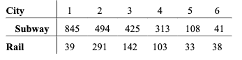

## Task 7 Solution:

## Step 1. Find the Spearman rank correlation coefficient:

```r
# Data for subways and commuter rails in the six cities
subway_trips <- c(845, 494, 425, 313, 108, 41)
rail_trips <- c(39, 291, 142, 103, 33, 38)

# Find the Spearman rank correlation coefficient.
rho <- cor(subway_trips, rail_trips, method = "spearman")

rho
```

```
## [1] 0.6
```

## Step 2. State the hypothesis:

- Null Hypothesis : There is no correlation between the number of daily passenger trips for subways and commuter rail service.
- Alternative Hypothesis : There is a correlation between the number of daily passenger trips for subways and commuter rail service.

## Step 3. Find the critical value:

```r
# Number of pairs
n_6 <- 6

# Significance level
alpha <- 0.05

# Two-tailed test multiplier for the normal distribution
z <- qnorm(1 - alpha / 2)

# Compute the critical value for Spearman's rank correlation using the normal approximation
spearman_critical_value <- z * (1 / sqrt(n_6 - 1))

# Print the critical value
spearman_critical_value
```

```
## [1] 0.8765225
```

## Step 4. Make the decision:

```r
decision_task7 <- ifelse(abs(rho) > spearman_critical_value, "Reject the null hypothesis", "Fail to Reject the null hypothesis")

# Print the decision and the value of rho
decision_task7
```

```
## [1] "Fail to Reject the null hypothesis"
```

```r
rho
```

```
## [1] 0.6
```

## Step 5. Summary:

**Q. Suggest one reason why the transportation authority might use the results of this study?**

A> The transportation authority might use the results of this study to inform their planning and resource allocation. Since the Spearman rank correlation coefficient of 0.6 suggests a positive but not statistically significant correlation between the number of daily passenger trips for subways and commuter rail service, the authority might conclude that while there is some relationship between the usage of the two services, it is not strong enough to warrant combining or integrating services based on current data.

One reason for using these results could be to evaluate whether efforts to promote one service (e.g., subways) might have a spillover effect on the usage of the other service (e.g., commuter rail). The absence of a strong correlation might lead to independent strategies for improving each service without the expectation that changes in one will necessarily affect the other. Alternatively, the results could also be used to identify potential for cross-promotion or joint ticketing if the authority was expecting a stronger relationship and the study prompts a reevaluation of their approach.

# *Section 14-3*

## Task 8 14-3.16 Prizes in Caramel Corn Boxes

A caramel corn company gives four different prizes, one in each box. They are placed in the boxes at  
random. Find the average number of boxes a person needs to buy to get all four prizes. (40)

## Task 8 Solution:

## **Step 1: Simulate a single experiment.**

- We’ll generate random numbers between 1 and 4, each representing a prize, and count how many boxes we need to buy until we have collected all four different prizes.

## **Step 2: Repeat the experiment.**

- We’ll repeat step 1 for 40 times to simulate 40 different trials.

```r
#below code is sourced from OpenAI,2024

set.seed(123) # Setting a seed for reproducibility

# Function to simulate one trial of buying boxes until all four prizes are collected
simulate_one_trial <- function() {
  prizes_collected <- numeric() # Vector to store collected prizes
  num_boxes <- 0 # Counter for the number of boxes bought

  # Repeat buying boxes until all four unique prizes are collected
  while(length(unique(prizes_collected)) < 4) {
    prize <- sample(1:4, 1) # Get a random prize (numbered 1 to 4)
    prizes_collected <- c(prizes_collected, prize) # Add the prize to the collection
    num_boxes <- num_boxes + 1 # Increment the box counter
  }

  return(num_boxes) # Return the total number of boxes bought in this trial
}

# Step 2: Repeat the experiment 40 times
num_trials <- 40
results_task8 <- replicate(num_trials, simulate_one_trial())

# Step 3: Calculate the average number of boxes needed
average_boxes <- mean(results_task8)

# Print the average
average_boxes
```

```
## [1] 7.975
```

## Step 3. Summary

The output indicates that, on average, approximately 7.975 (or about 8) boxes of caramel corn need to be purchased to collect all four unique prizes. This average is based on a simulation of the experiment conducted 40 times. Each simulation represents a sequence of purchases where a single box is bought at a time until a complete set of all four prizes is obtained.

## Task 9 14-3.18 Lottery Winner

To win a certain lotto, a person must spell the word big. Sixty percent of the tickets contain the letter b,  
30% contain the letter i, and 10% contain the letter g. Find the average number of tickets a person must  
buy to win the prize. (30).

## Task 9 Solution

## **Step 1: Simulate a single experiment.**

- Use random sampling to represent buying tickets, taking into account the different probabilities of getting each letter (60% for B, 30% for I, and 10% for G), and count the number of tickets bought until all three letters are collected.

## **Step 2: Repeat the experiment.**

- Repeat step 1 for 30 times to simulate 30 different trials.

```r
set.seed(123) # Setting a seed for reproducibility

# Function to simulate one trial of buying tickets until all three letters are collected
simulate_one_trial_1 <- function() {
  letters_collected<- character() # Vector to store collected letters
  num_tickets <- 0 # Counter for the number of tickets bought

  # Define the probabilities for each letter
  letters <- c("b", "i", "g")
  probabilities <- c(0.6, 0.3, 0.1)

  # Repeat buying tickets until all three unique letters are collected
  while(length(unique(letters_collected)) < 3) {
    letter <- sample(letters, 1, prob = probabilities) # Get a random letter based on the probabilities
    letters_collected <- c(letters_collected, letter) # Add the letter to the collection
    num_tickets <- num_tickets + 1 # Increment the ticket counter
  }

  return(num_tickets) # Return the total number of tickets bought in this trial
}

# Step 2: Repeat the experiment 30 times
num_trials <- 30
results_task9 <- replicate(num_trials, simulate_one_trial())

# Step 3: Calculate the average number of tickets needed
average_tickets <- mean(results_task9)

# Print the average
average_tickets
```

```
## [1] 7.533333
```

# Conclusion:

Upon completing the assignment, we have gained insights into the application and interpretation of nonparametric tests in various scenarios. The results from our analyses provided evidence to either reject or fail to reject our null hypotheses, allowing us to draw conclusions about the populations from which our samples were drawn.

# References:

1. OpenAI, 2024. *chat.openai*

   https://chat.openai.com/
2. Shapiro, V. *ALY6015_Module5_R_Tutorials_WinterA_2024* [.Rmd file].
3. Pre-Assignment Lab: Non-Parametric Statistics Video . *northeastern.instructure.com.*

   https://northeastern.instructure.com/courses/164824/assignments/2129240
4. Chi Yau. *Non-parametric Methods.* www.r-tutor.com/el

   https://www.r-tutor.com/elementary-statistics/non-parametric-methods